# Risk Factor Analysis

## Outcome Variable

**Outcome Variable:** haz

## Predictor Variables

**Intervention Variable:** fhtcm

**Adjustment Set:**

- arm
- W_mage
- W_fage
- meducyrs
- feducyrs
- W_mhtcm
- W_mwtkg
- W_mbmi
- single
- W_gagebrth
- W_birthwt
- W_birthlen
- vagbrth
- delta_W_mage
- delta_W_fage
- delta_meducyrs
- delta_feducyrs
- delta_W_mhtcm
- delta_W_mwtkg
- delta_W_mbmi
- delta_single
- delta_W_gagebrth
- delta_W_birthwt
- delta_W_birthlen
- delta_vagbrth

## Stratifying Variables

The analysis was stratified on these variable(s):

- agecat
- studyid
- country

## Data Summary

| agecat | studyid | country | fhtcm | n_cell | n |
| --- | --- | --- | --- | --- | --- |
| 6 months | COHORTS | GUATEMALA | >=167 cm | 45 | 336 |
| 6 months | COHORTS | GUATEMALA | <162 cm | 197 | 336 |
| 6 months | COHORTS | GUATEMALA | [162-167) cm | 94 | 336 |
| 6 months | Keneba | GAMBIA | >=167 cm | 979 | 1511 |
| 6 months | Keneba | GAMBIA | <162 cm | 113 | 1511 |
| 6 months | Keneba | GAMBIA | [162-167) cm | 419 | 1511 |
| 6 months | PROBIT | BELARUS | >=167 cm | 11146 | 11894 |
| 6 months | PROBIT | BELARUS | <162 cm | 156 | 11894 |
| 6 months | PROBIT | BELARUS | [162-167) cm | 592 | 11894 |
| 6 months | SAS-CompFeed | INDIA | >=167 cm | 369 | 807 |
| 6 months | SAS-CompFeed | INDIA | <162 cm | 194 | 807 |
| 6 months | SAS-CompFeed | INDIA | [162-167) cm | 244 | 807 |
| 6 months | SAS-FoodSuppl | INDIA | >=167 cm | 102 | 372 |
| 6 months | SAS-FoodSuppl | INDIA | <162 cm | 148 | 372 |
| 6 months | SAS-FoodSuppl | INDIA | [162-167) cm | 122 | 372 |
| 24 months | COHORTS | GUATEMALA | >=167 cm | 70 | 526 |
| 24 months | COHORTS | GUATEMALA | <162 cm | 307 | 526 |
| 24 months | COHORTS | GUATEMALA | [162-167) cm | 149 | 526 |
| 24 months | Keneba | GAMBIA | >=167 cm | 821 | 1297 |
| 24 months | Keneba | GAMBIA | <162 cm | 97 | 1297 |
| 24 months | Keneba | GAMBIA | [162-167) cm | 379 | 1297 |
| 24 months | PROBIT | BELARUS | >=167 cm | 3445 | 3670 |
| 24 months | PROBIT | BELARUS | <162 cm | 53 | 3670 |
| 24 months | PROBIT | BELARUS | [162-167) cm | 172 | 3670 |

The following strata were considered:

- agecat: 24 months, studyid: COHORTS, country: GUATEMALA
- agecat: 24 months, studyid: Keneba, country: GAMBIA
- agecat: 24 months, studyid: PROBIT, country: BELARUS
- agecat: 6 months, studyid: COHORTS, country: GUATEMALA
- agecat: 6 months, studyid: Keneba, country: GAMBIA
- agecat: 6 months, studyid: PROBIT, country: BELARUS
- agecat: 6 months, studyid: SAS-CompFeed, country: INDIA
- agecat: 6 months, studyid: SAS-FoodSuppl, country: INDIA

## Methods Detail

We’re interested in the causal parameters $E[Y_a]$ for all values of $a \in \mathcal{A}$. These parameters represent the mean outcome if, possibly contrary to fact, we intervened to set all units to have $A=a$. Under the randomization and positivity assumptions, these are identified by the statistical parameters $\psi_a=E_W[E_{Y|A,W}(Y|A=a,W)]$. In addition, we’re interested in the mean of $Y$, $E[Y]$ under no intervention (the observed mean). We will estimate these parameters by using SuperLearner to fit the relevant likelihood factors – $E_{Y|A,W}(Y|A=a,W)$ and $p(A=a|W)$, and then updating our likelihood fit using a joint TMLE.

For unadjusted analyses ($W=\{\}$), initial likelihoods were estimated using Lrnr_glm to estimate the simple $E(Y|A)$ and Lrnr_mean to estimate $p(A)$. For adjusted analyses, a small library containing Lrnr_glmnet, Lrnr_xgboost, and Lrnr_mean was used.

# Results Detail

## Results Plots

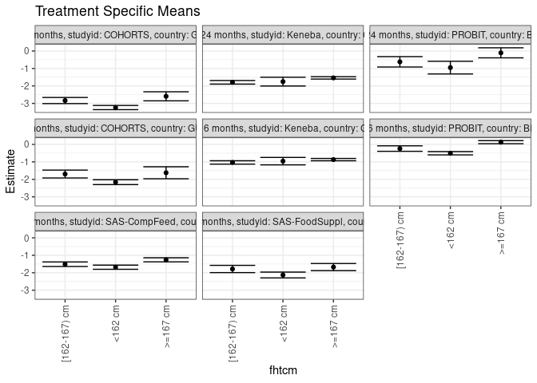

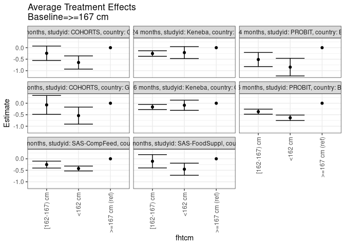

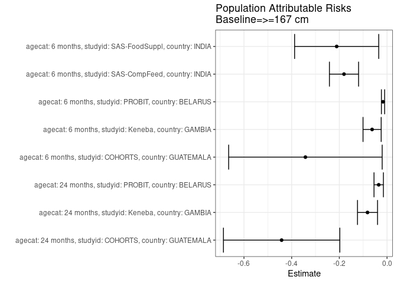

## Results Table

### Parameter: TSM

| agecat | studyid | country | intervention_level | baseline_level | estimate | ci_lower | ci_upper |
| --- | --- | --- | --- | --- | --- | --- | --- |
| 6 months | COHORTS | GUATEMALA | >=167 cm | NA | -1.6229692 | -1.9659094 | -1.2800290 |
| 6 months | COHORTS | GUATEMALA | <162 cm | NA | -2.1616347 | -2.3004453 | -2.0228241 |
| 6 months | COHORTS | GUATEMALA | [162-167) cm | NA | -1.6953611 | -1.9198965 | -1.4708257 |
| 6 months | Keneba | GAMBIA | >=167 cm | NA | -0.8695603 | -0.9360771 | -0.8030434 |
| 6 months | Keneba | GAMBIA | <162 cm | NA | -0.9578212 | -1.1705920 | -0.7450505 |
| 6 months | Keneba | GAMBIA | [162-167) cm | NA | -1.0325495 | -1.1287805 | -0.9363185 |
| 6 months | PROBIT | BELARUS | >=167 cm | NA | 0.1276713 | 0.0401645 | 0.2151782 |
| 6 months | PROBIT | BELARUS | <162 cm | NA | -0.5056371 | -0.5991266 | -0.4121476 |
| 6 months | PROBIT | BELARUS | [162-167) cm | NA | -0.2390448 | -0.3958122 | -0.0822774 |
| 6 months | SAS-CompFeed | INDIA | >=167 cm | NA | -1.2595870 | -1.3757957 | -1.1433784 |
| 6 months | SAS-CompFeed | INDIA | <162 cm | NA | -1.6829476 | -1.8022390 | -1.5636562 |
| 6 months | SAS-CompFeed | INDIA | [162-167) cm | NA | -1.5127075 | -1.6421457 | -1.3832694 |
| 6 months | SAS-FoodSuppl | INDIA | >=167 cm | NA | -1.6759080 | -1.8805527 | -1.4712634 |
| 6 months | SAS-FoodSuppl | INDIA | <162 cm | NA | -2.1297169 | -2.2968329 | -1.9626009 |
| 6 months | SAS-FoodSuppl | INDIA | [162-167) cm | NA | -1.7844188 | -1.9911381 | -1.5776995 |
| 24 months | COHORTS | GUATEMALA | >=167 cm | NA | -2.5926430 | -2.8517352 | -2.3335508 |
| 24 months | COHORTS | GUATEMALA | <162 cm | NA | -3.2370781 | -3.3580739 | -3.1160824 |
| 24 months | COHORTS | GUATEMALA | [162-167) cm | NA | -2.8355531 | -3.0109114 | -2.6601948 |
| 24 months | Keneba | GAMBIA | >=167 cm | NA | -1.5381844 | -1.6070900 | -1.4692789 |
| 24 months | Keneba | GAMBIA | <162 cm | NA | -1.7515804 | -2.0039810 | -1.4991798 |
| 24 months | Keneba | GAMBIA | [162-167) cm | NA | -1.7920656 | -1.8943268 | -1.6898045 |
| 24 months | PROBIT | BELARUS | >=167 cm | NA | -0.1040819 | -0.3924844 | 0.1843207 |
| 24 months | PROBIT | BELARUS | <162 cm | NA | -0.9497312 | -1.3135899 | -0.5858725 |
| 24 months | PROBIT | BELARUS | [162-167) cm | NA | -0.6191516 | -0.9158003 | -0.3225028 |

### Parameter: E(Y)

| agecat | studyid | country | intervention_level | baseline_level | estimate | ci_lower | ci_upper |
| --- | --- | --- | --- | --- | --- | --- | --- |
| 6 months | COHORTS | GUATEMALA | NA | NA | -1.9652976 | -2.0794998 | -1.8510954 |
| 6 months | Keneba | GAMBIA | NA | NA | -0.9321551 | -0.9872314 | -0.8770788 |
| 6 months | PROBIT | BELARUS | NA | NA | 0.1108245 | 0.0214240 | 0.2002250 |
| 6 months | SAS-CompFeed | INDIA | NA | NA | -1.4400743 | -1.5370187 | -1.3431300 |
| 6 months | SAS-FoodSuppl | INDIA | NA | NA | -1.8871505 | -1.9993302 | -1.7749709 |
| 24 months | COHORTS | GUATEMALA | NA | NA | -3.0347529 | -3.1289563 | -2.9405494 |
| 24 months | Keneba | GAMBIA | NA | NA | -1.6200950 | -1.6766111 | -1.5635788 |
| 24 months | PROBIT | BELARUS | NA | NA | -0.1390400 | -0.4237657 | 0.1456858 |

### Parameter: ATE

| agecat | studyid | country | intervention_level | baseline_level | estimate | ci_lower | ci_upper |
| --- | --- | --- | --- | --- | --- | --- | --- |
| 6 months | COHORTS | GUATEMALA | >=167 cm | >=167 cm | 0.0000000 | 0.0000000 | 0.0000000 |
| 6 months | COHORTS | GUATEMALA | <162 cm | >=167 cm | -0.5386655 | -0.9089495 | -0.1683814 |
| 6 months | COHORTS | GUATEMALA | [162-167) cm | >=167 cm | -0.0723919 | -0.4839693 | 0.3391854 |
| 6 months | Keneba | GAMBIA | >=167 cm | >=167 cm | 0.0000000 | 0.0000000 | 0.0000000 |
| 6 months | Keneba | GAMBIA | <162 cm | >=167 cm | -0.0882610 | -0.3102366 | 0.1337147 |
| 6 months | Keneba | GAMBIA | [162-167) cm | >=167 cm | -0.1629892 | -0.2754629 | -0.0505155 |
| 6 months | PROBIT | BELARUS | >=167 cm | >=167 cm | 0.0000000 | 0.0000000 | 0.0000000 |
| 6 months | PROBIT | BELARUS | <162 cm | >=167 cm | -0.6333084 | -0.7520803 | -0.5145365 |
| 6 months | PROBIT | BELARUS | [162-167) cm | >=167 cm | -0.3667162 | -0.4763475 | -0.2570849 |
| 6 months | SAS-CompFeed | INDIA | >=167 cm | >=167 cm | 0.0000000 | 0.0000000 | 0.0000000 |
| 6 months | SAS-CompFeed | INDIA | <162 cm | >=167 cm | -0.4233606 | -0.5295706 | -0.3171505 |
| 6 months | SAS-CompFeed | INDIA | [162-167) cm | >=167 cm | -0.2531205 | -0.4029614 | -0.1032797 |
| 6 months | SAS-FoodSuppl | INDIA | >=167 cm | >=167 cm | 0.0000000 | 0.0000000 | 0.0000000 |
| 6 months | SAS-FoodSuppl | INDIA | <162 cm | >=167 cm | -0.4538089 | -0.7163877 | -0.1912300 |
| 6 months | SAS-FoodSuppl | INDIA | [162-167) cm | >=167 cm | -0.1085108 | -0.3975010 | 0.1804795 |
| 24 months | COHORTS | GUATEMALA | >=167 cm | >=167 cm | 0.0000000 | 0.0000000 | 0.0000000 |
| 24 months | COHORTS | GUATEMALA | <162 cm | >=167 cm | -0.6444351 | -0.9305381 | -0.3583321 |
| 24 months | COHORTS | GUATEMALA | [162-167) cm | >=167 cm | -0.2429101 | -0.5562770 | 0.0704567 |
| 24 months | Keneba | GAMBIA | >=167 cm | >=167 cm | 0.0000000 | 0.0000000 | 0.0000000 |
| 24 months | Keneba | GAMBIA | <162 cm | >=167 cm | -0.2133960 | -0.4744347 | 0.0476428 |
| 24 months | Keneba | GAMBIA | [162-167) cm | >=167 cm | -0.2538812 | -0.3736643 | -0.1340981 |
| 24 months | PROBIT | BELARUS | >=167 cm | >=167 cm | 0.0000000 | 0.0000000 | 0.0000000 |
| 24 months | PROBIT | BELARUS | <162 cm | >=167 cm | -0.8456493 | -1.2290300 | -0.4622686 |
| 24 months | PROBIT | BELARUS | [162-167) cm | >=167 cm | -0.5150697 | -0.8224778 | -0.2076616 |

### Parameter: PAR

| agecat | studyid | country | intervention_level | baseline_level | estimate | ci_lower | ci_upper |
| --- | --- | --- | --- | --- | --- | --- | --- |
| 6 months | COHORTS | GUATEMALA | >=167 cm | NA | -0.3423284 | -0.6642552 | -0.0204017 |
| 6 months | Keneba | GAMBIA | >=167 cm | NA | -0.0625949 | -0.1006699 | -0.0245199 |
| 6 months | PROBIT | BELARUS | >=167 cm | NA | -0.0168468 | -0.0235805 | -0.0101132 |
| 6 months | SAS-CompFeed | INDIA | >=167 cm | NA | -0.1804873 | -0.2415708 | -0.1194039 |
| 6 months | SAS-FoodSuppl | INDIA | >=167 cm | NA | -0.2112425 | -0.3876303 | -0.0348547 |
| 24 months | COHORTS | GUATEMALA | >=167 cm | NA | -0.4421099 | -0.6861686 | -0.1980511 |
| 24 months | Keneba | GAMBIA | >=167 cm | NA | -0.0819105 | -0.1239477 | -0.0398733 |
| 24 months | PROBIT | BELARUS | >=167 cm | NA | -0.0349581 | -0.0546274 | -0.0152888 |